# Bayesian Statistics

# Beta Distribution

The **beta distribution** can be understood as representing a probability distribution of probabilities. That is, it represents all the possible values of a probability when we don’t know what that probability is. Let’s consider the following example:

## Prior & Posterior

Anyone who follows baseball is familiar with batting averages - simply the number of times a player gets a base hit divided by the number of times he goes up at bat (so it’s just a percentage between 0 and 1). .266 is in general considered an average batting average, while .300 is considered an excellent one.

Imagine we have a baseball player, and we want to predict what his season-long batting average will be. You might say we can just use his batting average so far, but this will be a very poor measure at the start of a season! If a player goes up to bat once and gets a single, his batting average is briefly 1.000, while if he strikes out or walks, his batting average is 0.000. It doesn’t get much better if you go up to bat for another five or six times, you could get a lucky streak and get an average of 1.000, or an unlucky streak and get an average of 0, neither of which are a remotely good predictor of how you will bat that season.

Given our batting average problem, which can be represented with a binomial distribution (a series of successes and failures), the best way to represent these prior is with the **beta distribution**. It’s saying, before we’ve seen the player take his first swing, what we roughly expect his batting average to be. The domain of the beta distribution is $(0, 1)$, just like a probability, so we already know we’re on the right track, but the appropriateness of the beta for this task goes far beyond that.

We expect that the player’s season-long batting average will be most likely around .27, but that it could reasonably range from .21 to .35. This can be represented with a **beta distribution** with parameters $\alpha=81$ and $\beta=219$. The two parameters were chosen based upon the fact that:

- The mean of the **beta distribution** is $\frac{\alpha}{\alpha+\beta}=\frac{81}{81+219}=.270$
- As you can see in the plot below, this distribution lies almost entirely within $(.2, .35)$, the reasonable range for a batting average.

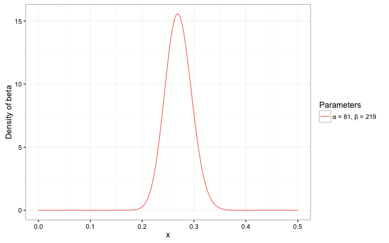

```r
library(ggplot2)
library(dplyr)

# synthesized data
# "\u03B1" unicode for the greek letter alpha
sim <- data.frame( a = c( 81, 82, 81 + 100 ),
                   b = c( 219, 219, 219 + 200 ) ) %>%
       group_by( a, b ) %>%
       do( data_frame( x = seq( 0, 1, by = .001 ), y = dbeta( x, .$a, .$b ) ) ) %>%
       mutate( Parameters = paste0( "\u03B1 = ", a, ", \u03B2 = ", b ) ) %>%
       ungroup() %>%
       mutate( Parameters = factor( Parameters, levels = unique(Parameters) ) )

# plot of the distribution
PlotBeta <- function(sim)
{
    ggplot( sim, aes( x, y, color = Parameters ) ) + geom_line() +
    xlim( 0, .5 ) + ylab("Density of beta") + theme_bw()
}
PlotBeta( sim = filter( sim, a == 81 ) )
```

In the preceding plot, the x axis in a **beta distribution** density plot represents a player’s batting average. Thus notice that in this case, not only is the y-axis a probability (or more precisely a probability density), but the x-axis is as well (batting average is just a probability of a hit, after all)! The **beta distribution** is representing a probability distribution of probabilities.

But here’s why the **beta distribution** is so appropriate. Imagine the player gets a single hit. His record for the season is now “1 hit; 1 at bat.” We have to then update our probabilities, we want to shift this entire curve over just a bit to reflect our new information. The new **beta distribution** will then become:

$$beta(\alpha_0 + hits, \beta_0 + misses)$$

Where $\alpha_0$ and $\beta_0$ are the parameters we started with, that is 81 and 219. Thus, in this case, $\alpha$ has increased by 1 (his one hit), while $\beta$ has not increased at all (no misses yet). That means our new distribution is $\beta(81+1, 219)$. Let’s compare that to the original:

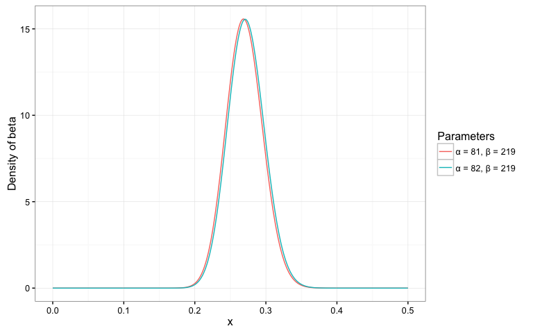

```r
# update 1 hit of 1 bat
PlotBeta( sim = filter( sim, a == 81 | a == 82 ) )
```

Notice that it has barely changed at all, that’s because one extra hit doesn’t really mean anything yet. However, the more the player hits over the course of the season, the more the curve will shift to accommodate the new evidence, and the furthermore more it will narrow based on the fact that we have more proof. Let’s say halfway through the season he has been up to bat 300 times, hitting 100 out of those times. The new distribution would be $\beta(81 + 100, 219 + 200)$:

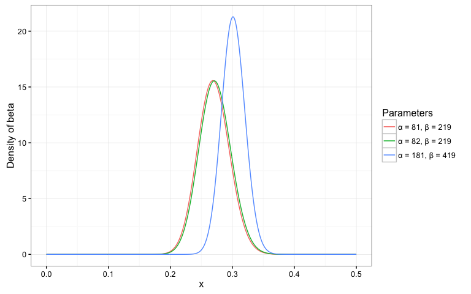

```r
# update 100 hit of 300 bat
PlotBeta( sim = sim )
```

Notice the curve is now both thinner and shifted to the right (higher batting average) than it used to be, since we now have a better sense of what the player’s batting average is most likely to be.

## Takeaways

- **Beta distribution** is only defined for values of x in the interval [0,1] and it is best for representing a probabilistic distribution of probabilities. Cases where we don’t know what a probability is in advance, but we have some reasonable guesses.
- A quick side note on the parameters for the **beta distribution**. As $\alpha$ gets bigger, the bulk of the distribution moves rightward over higher values of x, but as $\beta$ gets bigger, the bulk of the distribution moves leftward over lower values of x. And as $\alpha$ and $\beta$ get bigger together, the **beta distribution** gets narrower.

## Reference

1. Understanding the beta distribution http://varianceexplained.org/statistics/beta_distribution_and_baseball/

Ming-Yu Liu

2016-03-29